CS F364: Design and Analysis of Algorithms

# Introduction to Algorithms

Lecture 1 |2026-05-21

# Introduction

- Introduction
- Wrap-up

## Design and Analysis of Algorithms

- **Algorithm:** A well-defined procedure that transfers an input to an output.
  - Not a program: An algorithm can be implemented in several ways.
- **Design:** We will study methods/ideas/tricks for developing (fast!) algorithms.
- **Analysis:** Abstract/mathematical comparison of algorithms (without actually implementing them).

**Math is needed in three ways:**

1. For the formal definition of the problem.
2. For the analysis of correctness of algorithms.
3. For the analysis of efficiency (time, memory, …).

## Algorithms are fundamental

[figure not shown]

## Algorithms are useful

- **Foundational Knowledge:** Algorithms are the backbone of Computer Science.
- **Enhances problem solving skills:** We learn how to break down complex problems into simpler ones and design efficient solution.
- **Adaptability across domains:** Algorithmic thinking is applicable beyond coding in the fields like biology (understanding gene), finance (risk modeling), and logistics (route optimization). This adaptability makes it a versatile skill.
- **Career Advancements:** Algorithms are indispensable components in technical interviews. Excelling in algorithms can help secure roles in software development, data science, and other technical careers.

## Warm-up Problem - Integer multiplication

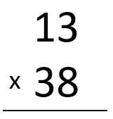

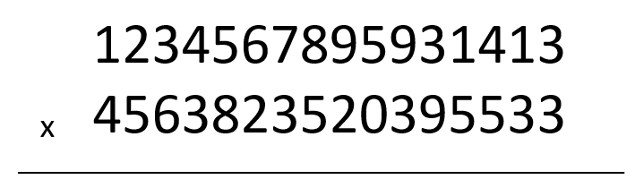

## Integer Multiplication

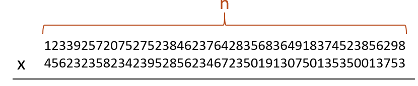

- About $n^2$ one-digit operations.
  - At most $n^2$ multiplications.
  - At most $n^2$ additions.
  - Add $n$ different $2n$ digit numbers.

## Complexity of multiplying two $n$ digit numbers

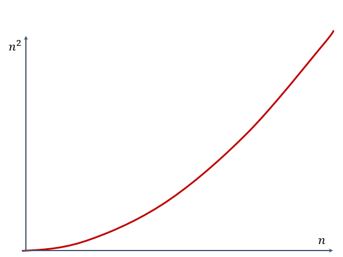

## Can we improve the complexity using Algorithmic toolkit?

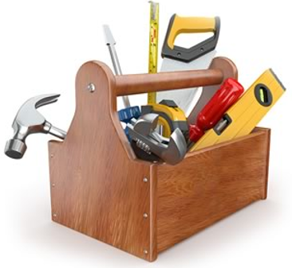

## Divide and conquer

*Break the problem into smaller (simpler) subproblems.*

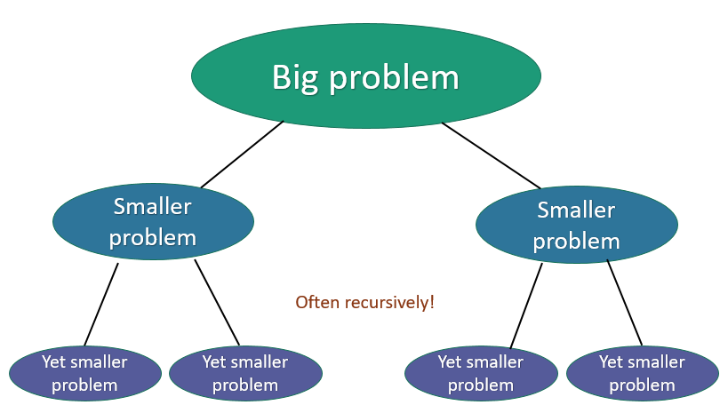

## Divide and conquer for multiplication

**Break up an integer:** $1234 = 12 \times 100 + 34$.

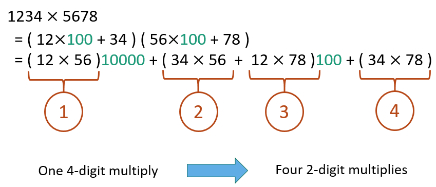

## More generally..

**Break up an $n$ digit integer**

$[x_1x_2\cdots x_n] = [x_1x_2\cdots x_{n/2}]\times 10^{n/2} + [x_{n/2+1}x_{n/2+2}\cdots x_n]$

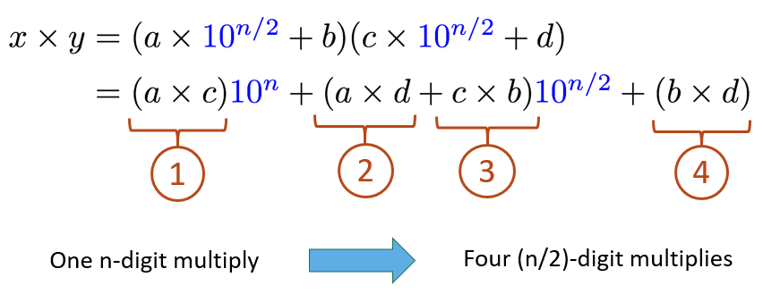

## Divide and conquer algorithm

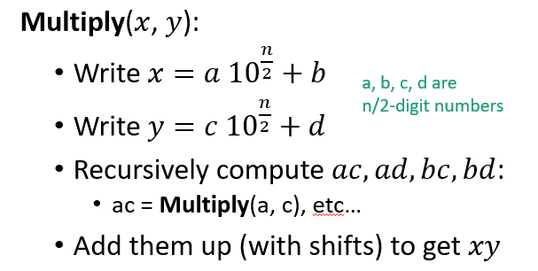

How long does this take?

## An Example

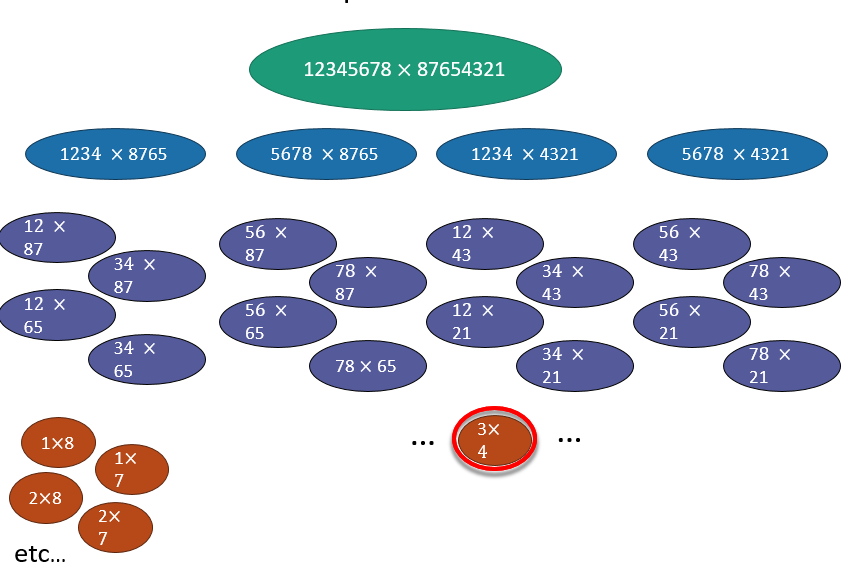

- *Claim: There are $n^2$ one-digit problems.*
- Every pair of digits still gets multiplied together separately.
- **The running time is still at least $n^2$.**

## Another way of looking this example

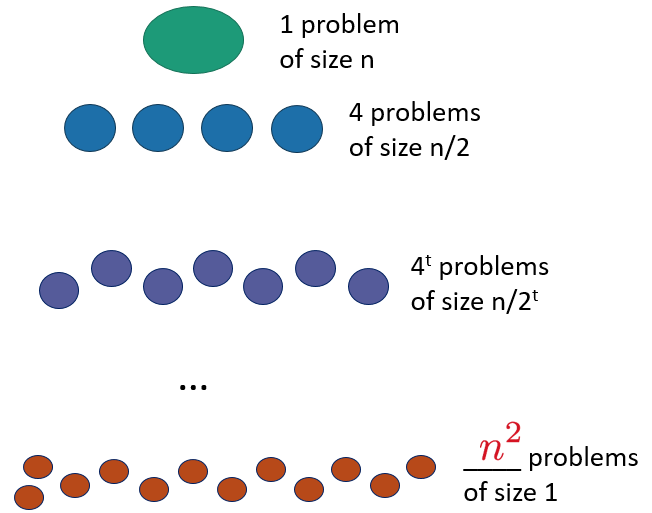

- *If we cut $n$ in half $\log_2{n}$ times, we get down to $1$.*
- *So, we do this $\log_2{n}$ times and get $4^{\log_2{n}} = n^2$ problems of size $1$.*

## Yet another way to see this

- Let $T(n)$ be the time to multiply two $n$-digit numbers.
- Recurrence: $T(n) = 4T(n/2) + \text{(time for adding things up)}$

Let us solve the recurrence:

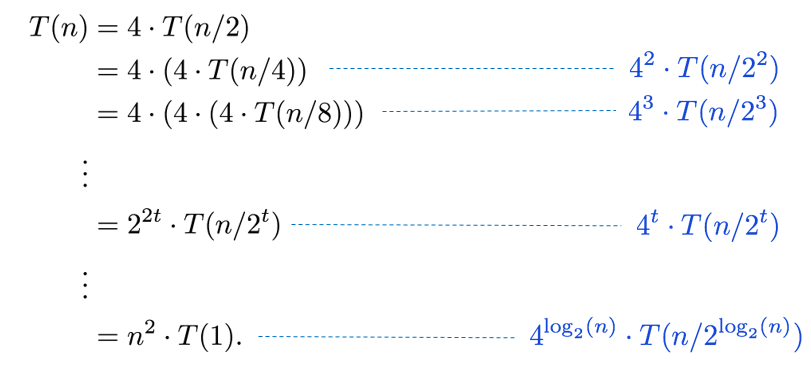

## Can we improve the time complexity from $n^2$?

- Karatsuba figured out the following:
- If we only recurse three times instead of four!

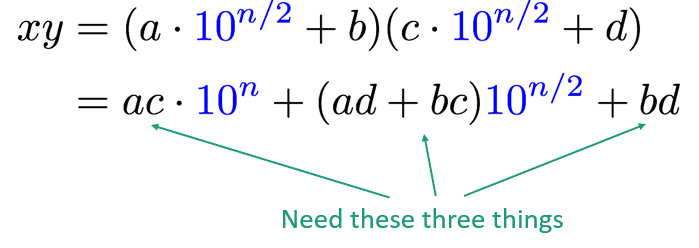

## Karatsuba algorithm for integer multiplication

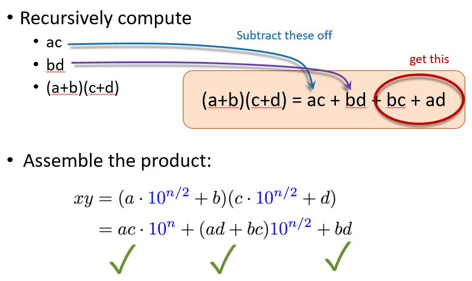

## Another way of looking this example

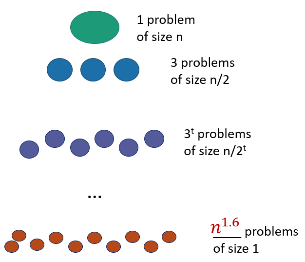

- *If we cut $n$ in half $\log_2{n}$ times, we get down to $1$.*
- *So, we do this $\log_2{n}$ times and get $3^{\log_2{n}} = n^{1.6}$ problems of size $1$.*

## This is much better

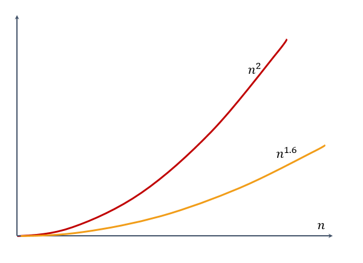

# Wrap-up

- Introduction
- Wrap-up

## Discussion Time!

Thank You!

Let’s discuss questions, clarifications, or any topics from today’s lecture.